# **Face Mask Detection Using YoloV5**

## **Team Members:** Tszchung Cheung, Abir Deb, Andrey Goryuk, Sufian Ilyas

- Problem Statement
- Dataset Retrieval
- Python Imports
- Dataset Exploration
- Dataset Preprocessing
- Modeling Details
- Model Training
- Model Results

# Problem Statement

With the global Covid pandemic raging on, many attempts have been made at curbing further spread, and with each, enforcement only getting harder. One such attempt is mandating mask wearing in public spaces. Our goal is to develop a machine learning model which utilizes computer vision to detect whether or not a person in an image or video feed is wearing a mask. As such, we will not only train a robust system that can detect human faces and mask wearing, it will also do so extremely efficiently such that it can be used with video for live detections from security cameras, as an example. Our final trained model is capable of predicting on video frames in around 35 milliseconds allowing for nearly 30 predicted frames per seconds all with impressive accuracy. The following notebook details the steps we took in producing this model.

# Dataset Retrieval

In the cell below, we download the dataset which is hosted on Google Drive and unzip it. The dataset was originally posted to [Kaggle](https://www.kaggle.com/wobotintelligence/face-mask-detection-dataset) which we downloaded and hosted to make it retrievable within the notebook.

```python
%%capture
!gdown --id 1iHTAMNJKYB__dCyYAF8sRoQL15Xi-eD7
!apt-get install tree
!unzip -q FaceMaskDataset.zip -d FaceMaskDataset
```

# Python Imports

The cell below imports all of the python libraries used.

```python
import cv2
import numpy as np
import os
import shutil
import json
from sklearn.model_selection import train_test_split
from google.colab.patches import cv2_imshow
import matplotlib.pyplot as plt
%matplotlib inline
```

The cell below imports our custom functions contained in a seperate python file called `utility_functions.py`. The python file is hosted on Google Drive and must first be downloaded.

```python
!gdown --id 1CqGNyWhpid8LWTBg91fLwyOvj00-ZXIo
```

```
Downloading...
From: https://drive.google.com/uc?id=1CqGNyWhpid8LWTBg91fLwyOvj00-ZXIo
To: /content/utility_functions.py
100% 3.38k/3.38k [00:00<00:00, 1.55MB/s]
```

```python
from utility_functions import *
```

# Dataset Exploration

The following section explores the format and structure of the dataset as it is given. It is key to understand how the dataset is structered since YoloV5 models require a certain format for training.

The dataset consists of several thousand images with each image having a corresponding json file which contains the bounding box data. The cell below is an example json file. The json file contains a filename attribute which is the name of the original image. It also contains an annotations array which gives the coordinates of the bounding box and its label.

```python
annotations = []

for jsonFile in os.listdir('/content/FaceMaskDataset/Medical mask/Medical mask/Medical Mask/annotations'):
  annotations.append(json.load(open(f'/content/FaceMaskDataset/Medical mask/Medical mask/Medical Mask/annotations/{jsonFile}')))

annotations[2]
```

```
{'Annotations': [{'Attributes': {},
   'BoundingBox': [367, 155, 445, 226],
   'Confidence': 1,
   'ID': 549965152426162048,
   'classname': 'mask_colorful',
   'isProtected': False},
  {'Attributes': {},
   'BoundingBox': [378, 119, 457, 160],
   'Confidence': 1,
   'ID': 9547259767263228,
   'classname': 'eyeglasses',
   'isProtected': False},
  {'Attributes': {},
   'BoundingBox': [334, 47, 461, 222],
   'Confidence': 1,
   'ID': 408675584482918720,
   'classname': 'face_with_mask_incorrect',
   'isProtected': False},
  {'Attributes': {},
   'BoundingBox': [946, 128, 1064, 207],
   'Confidence': 1,
   'ID': 450017138426603840,
   'classname': 'scarf_bandana',
   'isProtected': False},
  {'Attributes': {},
   'BoundingBox': [930, 25, 1051, 207],
   'Confidence': 1,
   'ID': 327996024339525120,
   'classname': 'face_other_covering',
   'isProtected': False}],
 'FileName': '6401.png',
 'NumOfAnno': 5}
```

The cell below gathers all of the unique class labels given in the dataset. This is a key step as we see that our dataset contains labels that are irrelevant to our project. For example, we do not need the label 'gas_mask' or 'hair_net'. In the preprocessing section, we extract only the images that contain the labels that we need which are 'face_mask' and 'face_no_mask'.

```python
uniqueClassNames = []

for annot in annotations:
  for i in annot['Annotations']:
    if i['classname'] not in uniqueClassNames:
      uniqueClassNames.append(i['classname'])

uniqueClassNames
```

```
['face_with_mask',
 'mask_surgical',
 'face_no_mask',
 'mask_colorful',
 'eyeglasses',
 'face_with_mask_incorrect',
 'scarf_bandana',
 'face_other_covering',
 'sunglasses',
 'hat',
 'turban',
 'balaclava_ski_mask',
 'helmet',
 'hijab_niqab',
 'goggles',
 'hood',
 'face_shield',
 'hair_net',
 'other',
 'gas_mask']
```

Below is an example of an image in our dataset. We can see it has 5 labels being 'mask_colorful', 'eyeglasses', 'face_with_mask_incorrect', 'scarf_bandana', and 'face_other_covering'. Each has a bounding box with the coordinates formatted as the location of the top left corner and the bottom right corner.

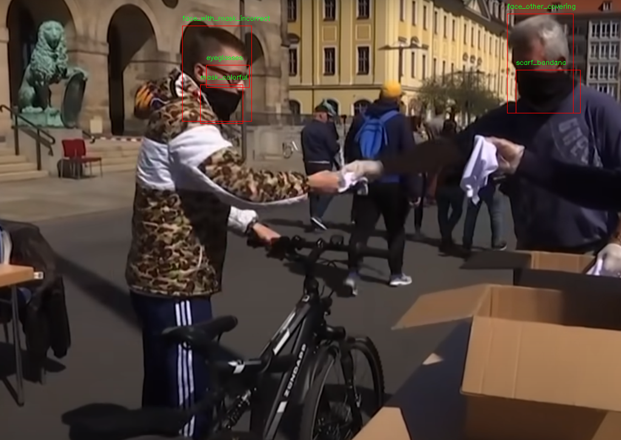

```python
sampleImgPath = '6401.png'
sampleImg = cv2.imread(f'/content/FaceMaskDataset/Medical mask/Medical mask/Medical Mask/images/{sampleImgPath}')

#adding bounding boxes for each annotation
for anot in annotations[2]['Annotations']:
  cv2.rectangle(sampleImg,(anot['BoundingBox'][0],anot['BoundingBox'][1]),(anot['BoundingBox'][2],anot['BoundingBox'][3]),(0,0,255),1)
  cv2.putText(sampleImg, anot['classname'] , (anot['BoundingBox'][0], anot['BoundingBox'][1]-10), cv2.FONT_HERSHEY_SIMPLEX, 0.4, (36,255,12), 1)

cv2_imshow(sampleImg)
```

```python
face_with_mask_count = 0
face_no_mask_count = 0

for annot in annotations:
  for i in annot['Annotations']:
    if i['classname'] == 'face_with_mask':
      face_with_mask_count += 1
    if i['classname'] == 'face_no_mask':
      face_no_mask_count += 1

print("Faces with mask annotation count: ", face_with_mask_count)
print("Faces with no mask annotation count: ", face_no_mask_count)
```

```
Faces with mask annotation count:  4180
Faces with no mask annotation count:  1569
```

The figure below shows the distribution of annotations in our final dataset. One thing to notice is that there are far more annotations for faces with masks than for faces without masks. With a model built from scratch, this would probably cause bias in the model's predictions. However, since we are using a pretrained model that already contains weights, this skewness in the training data is mitigated. The pretrained model that we retrain for our purpose is already capable of identifying people from images and video, so with our dataset, the model will adjust its weights and have a strong idea of what a person with a mask looks like.

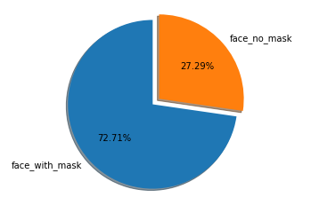

```python
labels = 'face_with_mask', 'face_no_mask',
sizes = [face_with_mask_count, face_no_mask_count]
explode = (0, 0.1,)

fig1, ax1 = plt.subplots()
ax1.pie(sizes, explode=explode, labels=labels, autopct='%1.2f%%',
        shadow=True, startangle=90)
ax1.axis('equal')

plt.show()
```

# Dataset Preprocessing

This section focuses on preparing the dataset for training with the YoloV5 architecture. This involves several steps with the first being filtering out the images with only our desired labels, shown in the cell below.

```python
valid_annotations = {'face_with_mask':0,
                     'face_no_mask':1,}

valid_image_files = []

for image in annotations:
  for data in image['Annotations']:
    if data['classname'] in valid_annotations.keys():
      valid_image_files.append(image['FileName'])
      break
```

Next, we create our training and test splits for the files that contain 'face_mask' and 'face_no_mask' only. We use a testing split of .2 so 80% of the images are used for training and 20% for validation.

```python
img_train, img_valid = train_test_split(valid_image_files,test_size=0.2, random_state=42)

print(len(img_train),len(img_valid))
```

```
2712 678
```

The cell below creates the file structure that is required for YoloV5. All of the images must be placed in the 'images' directory and labels in the 'labels' directory. These directories are split into training and validation folders. Images are connected to their labels via the filename. Each image has a corresponding .txt file with the same name which contains the bounding box information in Yolo format.

```python
%%capture
os.getcwd()
!mkdir Yolov5_data
%cd Yolov5_data
!mkdir images
!mkdir labels
%cd images
!mkdir training
!mkdir validation
%cd ..
%cd labels
!mkdir training
!mkdir validation
%cd ..
%cd ..
```

```python
!tree Yolov5_data
```

```
Yolov5_data
├── images
│   ├── training
│   └── validation
└── labels
    ├── training
    └── validation

6 directories, 0 files
```

The cells below preprocess the images and generates their corresponding .txt files in Yolo format to be accepted by the Yolo architecture. First, images are resized to 512px x 512px to speed up training. Then, the bounding box coordinates are scaled so that they line up with the resized images. Next, the coordinates of the bounding boxes are reformatted so that they are now four values with the first two representing the x and y coordinates of the center of the bounding box and the next two values being the width and height of the bounding box from the center. The values are also scaled to be between 0 and 1. Finally, the label of the bounding box is encoded with a 0 representing 'face_with_mask' and 1 representing 'face_no_mask'. If an image has multiple annotations then a new row is included in the .txt file with the five values encoding information about the bounding boxes.

```python
preprocess("training", img_train, img_valid, valid_annotations)
```

```
2712
2712
```

```python
preprocess("validation", img_train, img_valid, valid_annotations)
```

```
678
678
```

After the preprocessing, we noticed that there are some duplicate images with different file types. For example, we had img101.jpg and img101.png and only one annotation file img101.txt. The cell below deletes the duplicate files keeping only the jpg version.

```python
remove_duplicates()
```

Finally we check to see that all of the directories are synchronized.

```python
print("\nAfter preprocessing we have:")
print("Training image: ",len(os.listdir('/content/Yolov5_data/images/training/')))
print("Training labels: ",len(os.listdir('/content/Yolov5_data/labels/training/')))
print("Validation image: ",len(os.listdir('/content/Yolov5_data/images/validation/')))
print("Validation labels: ",len(os.listdir('/content/Yolov5_data/labels/validation/')))
```

```
After preprocessing we have:
Training image:  2709
Training labels:  2709
Validation image:  678
Validation labels:  678
```

# Modeling Details

A major aspect of this project is to not only detect people with and without face masks, but to also do it extremely quickly such that it can work efficiently with video streams. We decided to utilize the YoloV5 framework, which according to its documentation, is capable of rapid predictions with inference times low enough to support 60 frames per second. YoloV5 comes with various model sizes all of which were pretrained on the COCO val2017 dataset. These models come with pretrained weights for numerous classes such as people, cars, and bikes among many others. Below is an image from the [YoloV5 Docs](https://github.com/ultralytics/yolov5/wiki/Train-Custom-Data) comparing the various pretrained models. For this project, we retrained the YoloV5 small model as it strikes a good balance between low inference times and complexity.

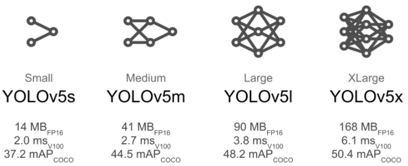

# Model Training

The cell below clones the YoloV5 github which contains all of the files needed to train a model.

```python
%%capture
!git clone https://github.com/ultralytics/yolov5
%cd yolov5
!pip install -r requirements.txt
!pip install PyYAML
```

Below, our custom yaml file is downloaded. The yaml file specifies which directories are for training and validation. It also defines the number of classes, which is 2 (face with mask and face with no mask), and the target label names (Mask and No_Mask).

```python
%cd /content/yolov5
!gdown --id 1zKtD7_2F9GfJZsecT9cdZghMr7osbxpa
```

```
/content/yolov5
Downloading...
From: https://drive.google.com/uc?id=1zKtD7_2F9GfJZsecT9cdZghMr7osbxpa
To: /content/yolov5/face_mask.yaml
100% 125/125 [00:00<00:00, 301kB/s]
```

The following cell trains our face mask detection model. Some parameters used are 100 epochs, a batch size of 32, and image size of 512. The console output is hidden to avoid hundreds of lines of output.

```python
%%capture
!python train.py --img 512 --batch 32 --epochs 100 --data face_mask.yaml --weights yolov5s.pt --name FaceMask
```

# Model Results

Once the model is done training, a `best.pt` weights file is produced. It can be seen in the image below. This `best.pt` file can now be loaded using PyTorch hub and predictions can be done on any image.

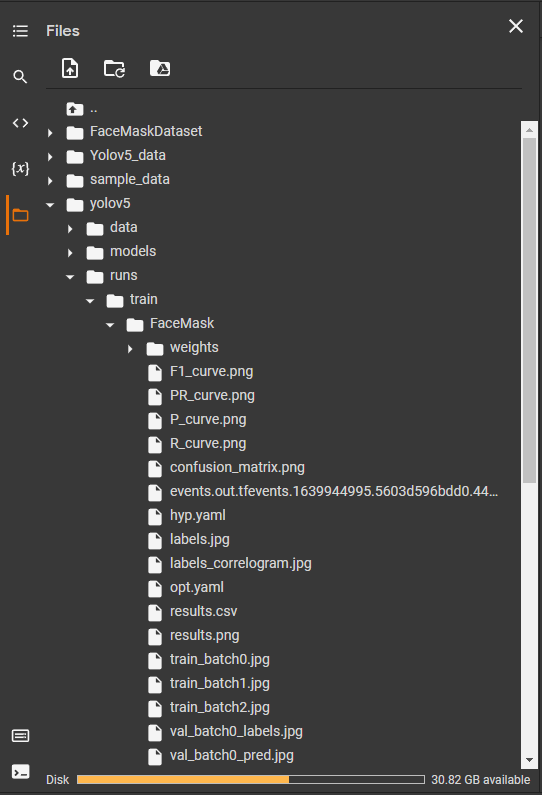

Once the model is done training, YoloV5 prints the metrics from the final epoch. Some of the metrics used to measure model performance are precision, recall, and mean average precision. The model finished with .88 precision on all classes, .92 precision on the mask class, and .845 precision on the no_mask class. The final recall followed a similar trend with the lowest being on the no_mask class.

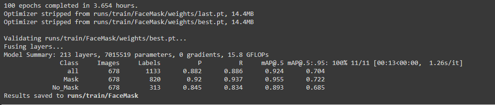

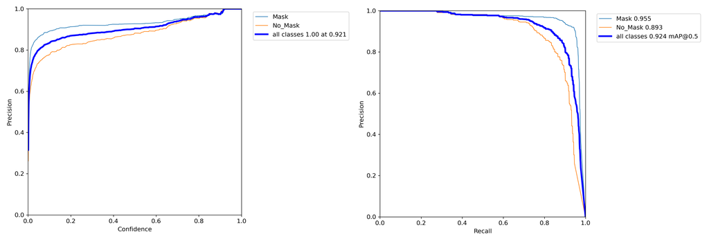

In the cells below, we can see how the model predicted on certain validation images versus their ground truth. Furthermore, we can see the model's confidence level.

## Model Predictions

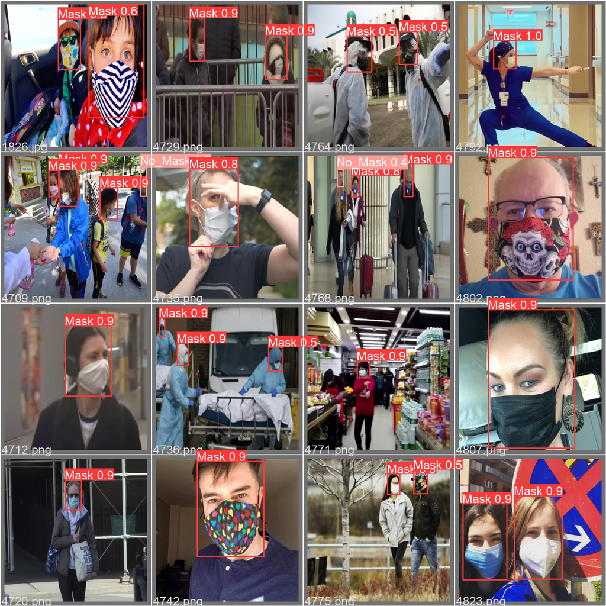

## Ground Truth

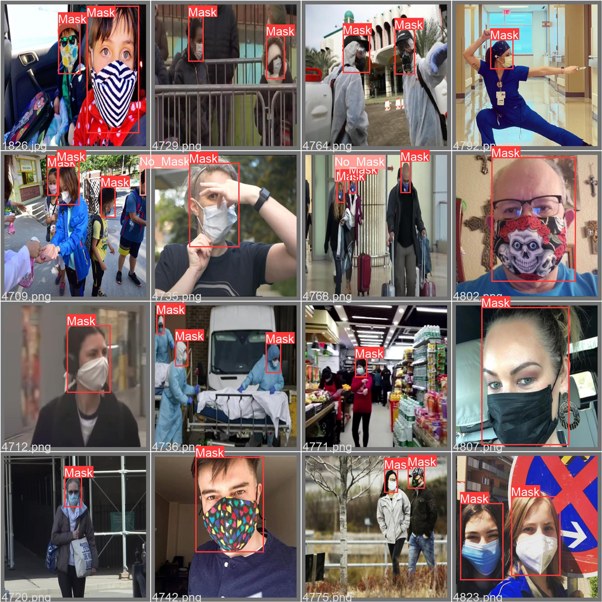

## Model Observations

After deploying the model to our webapp and testing it exhaustively with images found from google, there were a few things that we noticed. First, the model would sometimes predict on people from behind despite not having a view of a persons face. We believe this is a by-product of using a pretrained model. The pretrained model has weights to detect people, and in our training dataset, every person that it detected would either be classified as wearing or not wearing a mask. So, the model learned that a mask can only be detected after a person is detected therefore predicting despite not having a view of the person's face. Furthermore, we also noticed it was a bit weaker in detecting the no_mask class which follows with the metrics for that class being lower. The model would struggle more to identify people without a mask from a further distance.